# Projekt WB

Adam Rydelek, Piotr Miziński

24 - 04 - 2019

# 1 Wprowadzenie

Aby rozwiązać problem wyznaczenia najlepszego modelu predykcji zadanego datasetu uznaliśmy, że będziemy szukać podobieństw między naszym *tajemniczym* datasetem, a innymi, bardziej znanymi datasetami. Najpierw zobaczmy, jak wygląda ta ramka danych:

```r
summary(df)
```

```
##      Y              Zuzanna            Julia              Lena
##  Mode :logical   Min.   :0.00000   Min.   :0.00000   Min.   :20.00
##  FALSE:4184      1st Qu.:0.00000   1st Qu.:0.00000   1st Qu.:63.00
##                  Median :0.00000   Median :0.00000   Median :71.00
##                  Mean   :0.05569   Mean   :0.05569   Mean   :69.25
##                  3rd Qu.:0.00000   3rd Qu.:0.00000   3rd Qu.:80.00
##                  Max.   :1.00000   Max.   :1.00000   Max.   :94.00
##       Maja            Hanna            Zofia            Amelia
##  Min.   :  0.00   Min.   :  0.00   Min.   : 20.00   Min.   :  0.0
##  1st Qu.:  6.00   1st Qu.: 52.00   1st Qu.: 87.00   1st Qu.:117.0
##  Median : 25.00   Median : 73.00   Median : 96.00   Median :176.0
##  Mean   : 32.28   Mean   : 74.08   Mean   : 88.36   Mean   :183.3
##  3rd Qu.: 53.00   3rd Qu.: 95.00   3rd Qu.:100.00   3rd Qu.:247.0
##  Max.   :154.00   Max.   :258.00   Max.   :100.00   Max.   :603.0
##      Alicja         Aleksandra         Natalia           Oliwia
##  Min.   : 0.000   Min.   :0.00000   Min.   :0.0000   Min.   :0.00000
##  1st Qu.: 0.000   1st Qu.:0.00000   1st Qu.:0.0000   1st Qu.:0.00000
##  Median : 1.000   Median :0.00000   Median :0.0000   Median :0.00000
##  Mean   : 1.288   Mean   :0.05688   Mean   :0.0729   Mean   :0.05569
##  3rd Qu.: 2.000   3rd Qu.:0.00000   3rd Qu.:0.0000   3rd Qu.:0.00000
##  Max.   :20.000   Max.   :1.00000   Max.   :1.0000   Max.   :1.00000
##      Maria            Wiktoria          Emilia        Antonina
##  Min.   :0.00000   Min.   :  0.00   Min.   : 0.0   Min.   :  0.00
##  1st Qu.:0.00000   1st Qu.: 50.00   1st Qu.: 0.0   1st Qu.: 20.00
##  Median :0.00000   Median : 67.00   Median : 0.0   Median : 31.00
##  Mean   :0.05569   Mean   : 62.79   Mean   :10.6   Mean   : 32.81
##  3rd Qu.:0.00000   3rd Qu.: 82.00   3rd Qu.:13.0   3rd Qu.: 45.00
##  Max.   :1.00000   Max.   :100.00   Max.   :83.0   Max.   :100.00
##      Laura             Anna           Nadia              Pola
##  Min.   :  0.00   Min.   :0.000   Min.   :0.00000   Min.   :0.00000
##  1st Qu.: 12.00   1st Qu.:5.000   1st Qu.:0.00000   1st Qu.:0.00000
##  Median : 20.00   Median :6.000   Median :0.00000   Median :0.00000
##  Mean   : 21.17   Mean   :6.022   Mean   :0.08174   Mean   :0.05736
##  3rd Qu.: 29.00   3rd Qu.:8.000   3rd Qu.:0.00000   3rd Qu.:0.00000
##  Max.   :100.00   Max.   :8.000   Max.   :1.00000   Max.   :1.00000
##     Liliana           Nikola           Gabriela
##  Min.   :0.0000   Min.   :0.00000   Min.   :0.00000
##  1st Qu.:0.0000   1st Qu.:0.00000   1st Qu.:0.00000
##  Median :1.0000   Median :0.00000   Median :0.00000
##  Mean   :0.5246   Mean   :0.05569   Mean   :0.05569
##  3rd Qu.:1.0000   3rd Qu.:0.00000   3rd Qu.:0.00000
##  Max.   :1.0000   Max.   :1.00000   Max.   :1.00000
```

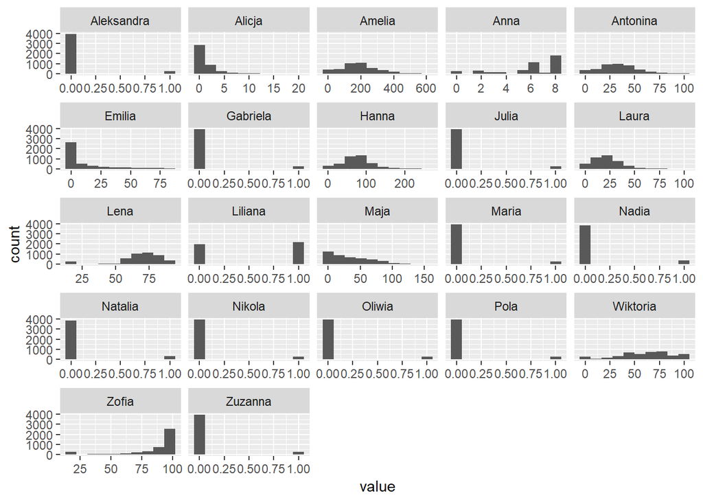

```r
ggplot(gather(select(df,-Y)), aes(value)) + geom_histogram(bins = 10) + facet_wrap(~key, scales = 'free_x')
```

# 2 Pierwsze rozwiązanie

Punktem wyjścia była liczba instancji, liczba kolumn kategorycznych, liczba kolumn numerycznych, oraz liczba brakujących instancji i wierszy. Zaczęliśmy od wzięcia pod uwagę naszego zbioru modeli utworzonych na zajęciach i zaczęliśmy szukać najbardziej podobnych datasetów za pomocą **knn**.

```r
### audit
#pobieramy pliki audit
files <- list.files(pattern = "audit\\.json$", recursive=TRUE)

#data.frame liczba auditow o danej liczbie kollumn i dugi dla blednych auditow
bledne <- data.frame("nr" = 0)
dobre <- data.frame("nr" = 0)

#data.framy dla regresji i klasyfikacji
dC <- fromJSON(files[2])
dC <- cbind(dC,dC$performance)
dC <- select(dC,-performance)

#petelka, zeby miec numery plikow
for(i in 1:length(files)){

  p <- fromJSON(files[i])
  p <- cbind(p,p$performance)
  p <- select(p,-performance)

  names(p) <- tolower(names(p))

  if(ncol(p) == 12){
      dC <- rbind(dC,p)
      dobre <- rbind(dobre,data.frame("nr" = i))
  }

  if(ncol(p) != 10){
    if(ncol(p) != 12){
      bledne <- rbind(bledne,data.frame("nr" = i))
    }
  }

}

#unique

bledne <- unique(bledne)[-1,]
dobre <- unique(dobre)[-1,]
dC <- unique(dC)

###model
#pobieramy pliki audit
filesM <- list.files(pattern = "model\\.json$", recursive=TRUE)

#data.frame liczba auditow o danej liczbie kollumn i dugi dla blednych auditow
ncM <- data.frame("ncol" = 0)
bledneM <- data.frame("nr" = 0)
dobreM <- data.frame("nr" = 0)

dM <- fromJSON(filesM[1])

#przygotowanie zbioru, piwerwszy wiersz
dMClean <- select(dM, id, library, model_name, task_id, dataset_id)
pre <- dM$preprocessing
dMClean$nC <- ncol(pre)

ncat =0
nnum = 0
for(i in names(pre)){
  a<-pre[i]
  a<-a[,1]
  if(a$type == c("categorical")){
    ncat =  ncat + 1
  }
  else{
    nnum = nnum + 1
  }
}

dMClean$ncat <- ncat
dMClean$nnum <- nnum
names(dMClean) <- tolower(names(dMClean))
#

for(j in 2:length(filesM)){

  dM <- fromJSON(filesM[j])
  pre <- dM$preprocessing

  if(ncol(dM) == 9){
    if(colnames(dM)[5] == "model"){
      colnames(dM)[5] <- "model_name"
    }

    dMCleanH <- select(dM, id, library, model_name, task_id, dataset_id)

    #liczba i rodzaj kolumn
    dMCleanH$nC <- ncol(pre)
    ncat =0
    nnum = 0
    for(i in names(pre)){
      a<-pre[i]
      a<-a[,1]
      if(a$type == c("categorical")){
        ncat =  ncat + 1
      }
      else{
        nnum = nnum + 1
      }
    }

    dMCleanH$ncat <- ncat
    dMCleanH$nnum <- nnum

    #laczenie
    names(dMCleanH) <- tolower(names(dMCleanH))
    if(all(names(dMCleanH) == names(dMClean))){
      dMClean <- rbind(dMClean,dMCleanH)
      dobreM <- rbind(dobreM,data.frame("nr" = j))
    }
    else{
      bledneM <- rbind(bledneM,data.frame("nr" = j))
    }
  }

}

dMClean <- unique(dMClean)

#laczenie zbiorow
kC <- left_join(dC, dMClean, by = c("model_id" = "id"))

kC <- kC[!is.na(kC$model_name),]

mod <- select(kC, -c(id, model_id, task_id.y, dataset_id.y))

mod[sapply(mod, is.character)] <- lapply(mod[sapply(mod, is.character)],
                                         as.factor)
mod <- mod[!is.na(mod$auc),]
mod <- mod[,4:ncol(mod)]
mod <- mod[,-(4:7)]

#datsetjson
filesDS <- list.files(pattern = "dataset\\.json$", recursive=TRUE)

dDS <- fromJSON(filesDS[1])

#przygotowanie zbioru, piwerwszy wiersz
dDS <- select(dDS, id, number_of_instances, number_of_missing_values, number_of_instances_with_missing_values)

for(k in 2:length(filesDS)){
  p <- fromJSON(filesDS[k])
  p <- select(p, id, number_of_instances, number_of_missing_values, number_of_instances_with_missing_values)

  dDS <- rbind(dDS,p)
}

mod$dataset_id.x <- as.character(mod$dataset_id.x)
dDS$id <- as.character(dDS$id)

data <- left_join(mod, dDS, by = c("dataset_id.x" = "id"))
data <- data[!is.na(data$number_of_instances),]
#data <- data[,-1]
data <- data %>% filter(library == "mlr")
data <- data[,-4]


#### datasety
##baza
datasety <- data[,-c(2,3,4,5)]
datasety <- unique(datasety)


##nasz

daneTest <- read.csv("WarsztatyBadawcze_test.csv",na.strings=c(""," ","NA"),sep=";")

#noiTrain <- nrow(daneTrain)
#nomvTrain <- sum(is.na(daneTrain))
#noiwmv <- sum(!complete.cases(daneTrain))
noiTrain <- 4184*4
nomvTrain <- 0
noiwmv <- 0


frameTest <- data.frame(datasetid.x="test",ncat=13,nnum=9,number_of_instances=noiTrain,
                    number_of_missing_values=nomvTrain, number_of_instances_with_missing_values=noiwmv)

scaledDatasety <- datasety
scaledDatasety[,2:6] <- scale(scaledDatasety[,2:6])
scaledFrameTest <- frameTest
scaledFrameTest[,2:6] <- scale(scaledFrameTest[,2:6])


distToPoint <- function(X, y,p){
  #funkcja obliczajaca odleglosc od punktow
  X <- matrix(as.numeric(unlist(X)),nrow=nrow(X))
  y <- matrix(as.numeric(unlist(y)),nrow=nrow(y))

  Y <- abs(X - matrix(y, byrow = TRUE,
                      nrow=nrow(X),
                      ncol=length(y)))^p
  rowSums(Y)^(1/p)
}

knnP <- function(X,Z,k,p=2){
  #x-train
  #z-test
  #kolumna odpowiedzi
  y <- X$dataset_id.x
  X <- X[,-1]
  Z <- Z[,-1]
  m<-matrix(nrow=nrow(Z),ncol=k)
  for (i in 1:nrow(Z)){
    m[i,] <- head(y[order(distToPoint(X,Z[i,],p))],k)
  }
  m
}

knnP2 <- function(X,Z,k,p=2){
  #x-train
  #z-test
  #kolumna odpowiedzi
  y <- X$id
  X <- X[,-1]
  Z <- Z[,-1]
  m<-matrix(nrow=nrow(Z),ncol=k)
  for (i in 1:nrow(Z)){
    m[i,] <- head(y[order(distToPoint(X,Z[i,],p))],k)
  }
  m
}


datasetyPodobne <- knnP(scaledDatasety,scaledFrameTest,5)[1,]
datasetyK <- data %>% filter(dataset_id.x %in% datasetyPodobne)
DT::datatable(datasetyK)
```

|  | dataset_id.x | acc | auc | model_name | nc | ncat | nnum | number_of_instances | number_of_missing_values | number_of_instances_with_missing_values |
| --- | --- | --- | --- | --- | --- | --- | --- | --- | --- | --- |
| 1 | kaggle_beauty | 0.7063 | 0.7409 | classif.binomial | 10 | 4 | 6 | 1260 | 0 | 0 |
| 2 | kaggle_pokemon | 0.9397 | 0.9644 | classif.svm | 10 | 3 | 7 | 800 | 387 | 386 |
| 3 | kaggle_pokemon | 0.9203 | 0.9527 | classif.gbm | 10 | 3 | 7 | 800 | 387 | 386 |
| 4 | kaggle_pokemon | 0.9204 | 0.9538 | classif.rda | 10 | 3 | 7 | 800 | 387 | 386 |
| 5 | kaggle_pokemon | 0.9324 | 0.9399 | classif.mda | 10 | 3 | 7 | 800 | 387 | 386 |
| 6 | kaggle_Toy-Dataset | 0.6722 | 0.7286 | classif.gbm | 5 | 3 | 2 | 150000 | 0 | 0 |
| 7 | kaggle_Toy-Dataset | 0.6739 | 0.7239 | classif.gbm | 5 | 3 | 2 | 150000 | 0 | 0 |
| 8 | kaggle_Toy-Dataset | 0.6951 | 0.7589 | classif.gbm | 5 | 3 | 2 | 150000 | 0 | 0 |
| 9 | openml_auto_price | 0.9685 | 0.9965 | classif.svm | 16 | 2 | 14 | 159 | 0 | 0 |
| 10 | openml_auto_price | 0.9185 | 0.9944 | classif.svm | 16 | 2 | 14 | 159 | 0 | 0 |

[output cut: 44 more lines]

Wyniki które otrzymaliśmy niezadowoliły nas jednak, ponieważ uznaliśmy, że zbiory, które znaleźliśmy są zbyt odmienne od naszego datasetu, dlatego przyjęliśmy inną taktykę.

# 3 Drugie rozwiazanie

Tym razem uznaliśmy, że potrzebujemy szerszego zbioru datasetów do porównań i dlatego stworzyliśmy algorytm zbierający dane takie jak: *liczba instancji*, *liczba kolumn kategorycznych z 2 unikalnymi wartościami*, *liczba kolumn kategorycznych z wiąkszą ilością unikalnych wartości*, *liczba kolumn numerycznych*, *liczba wierszy z NA*, *liczba instancji z NA* z datasetów **OpenML’a** o ID należącym do przedziału od 1 do 50000. Otrzymaliśmy w ten sposób **1789** datasetów, które łącznie ważyły 40GB i na podstawie ich własności powstała następująca ramka danych:

```r
z <- data.frame(id=0, ncat2 = 0, ncatwiecej = 0, nnum = 0, ninst = 0, missing_val=0, missing_inst=0)
for (i in 1:50000){
tryCatch({
x <- OpenML::getOMLDataSet(i)
x <- x$data
y <- data.frame(id=i, ncat2 = 0, ncatwiecej = 0, nnum = 0, ninst = 0, missing_val=0, missing_inst=0)
if(any(is.na(x))==FALSE){
  for(j in 1:length(x[1,])){
    if(length(unique(x[,j]))<=2){
      y$ncat2 = y$ncat2+1
    } else {
      if(length(unique(x[,j]))<=20) {
        y$ncatwiecej = y$ncatwiecej+1
      } else {
        if(length(unique(x[,j]))>20) {
          y$nnum = y$nnum+1
        }
      }
    }
  }
  y$missing_val = sum(is.na(x))
  y$missing_inst = nrow(x)-length(which(complete.cases(x)))
  y$ninst = length(x[,1])
}
z=rbind(z,y)
}, error=function(e){cat("ERROR :",conditionMessage(e), "\n", "ID = ", i)})
}
```

```r
zcalosc <- read.csv("datasetycalosc.csv")
zcalosc <- select(zcalosc, -X)
DT::datatable(zcalosc)
```

|  | id | ncat2 | ncatwiecej | nnum | ninst | missing_val | missing_inst |
| --- | --- | --- | --- | --- | --- | --- | --- |
| 1 | 0 | 0 | 0 | 0 | 0 | 0 | 0 |
| 2 | 1 | 21 | 15 | 3 | 898 | 0 | 0 |
| 3 | 2 | 0 | 0 | 0 | 0 | 0 | 0 |
| 4 | 3 | 36 | 1 | 0 | 3196 | 0 | 0 |
| 5 | 4 | 0 | 0 | 0 | 0 | 0 | 0 |
| 6 | 5 | 0 | 0 | 0 | 0 | 0 | 0 |
| 7 | 6 | 0 | 16 | 1 | 20000 | 0 | 0 |
| 8 | 7 | 0 | 0 | 0 | 0 | 0 | 0 |
| 9 | 8 | 1 | 1 | 5 | 345 | 0 | 0 |
| 10 | 9 | 0 | 0 | 0 | 0 | 0 | 0 |

[output cut: 1779 more lines]

Na jej podstawie z wykorzystaniem ponownie **knn’ów**, oraz zwykłej filtracji za pomocą `dplyr'a` otrzymaliśmy 5 najbardziej podobnych ramek danych o ID: *269*, *40676*, *40497*, *40878*, *40738*.

```r
zcalosc %>% filter(id %in% c(269,40676,40497,40878,40738))
```

| id | ncat2 | ncatwiecej | nnum | ninst | missing_val | missing_inst |
| --- | --- | --- | --- | --- | --- | --- |
| 269 | 14 | 0 | 6 | 1000000 | 0 | 0 |
| 40497 | 15 | 1 | 6 | 3772 | 0 | 0 |
| 40676 | 18 | 1 | 7 | 3163 | 0 | 0 |
| 40738 | 12 | 0 | 11 | 240 | 0 | 0 |
| 40878 | 7 | 6 | 6 | 2584 | 0 | 0 |

Następnie na każdej z powyższych ramek danych przetrenowaliśmy 5 różnych modeli wybranych na podstawie wyników pracy domowej, a ich wyniki zebraliśmy w ramce danych. Po dokładnym przejrzeniu datasetów uznaliśmy zbiór o ID równym *40676* za najbardziej podobny. Wyciągneliśmy ten wniosek za pomocą pakietu `dataMaid` i funkcji **makeDataReport()**. Poniżej można zauważyć krótkie podsumowanie tego zbioru i jego podobieństwo do naszego datasetu.

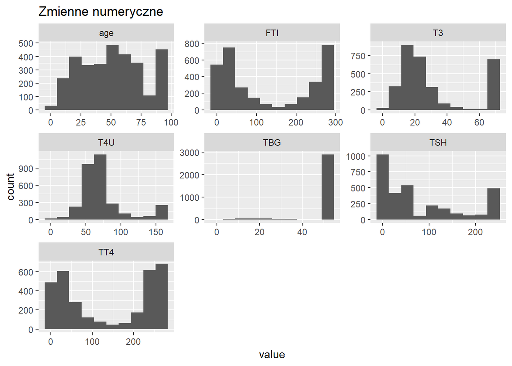

```r
podobny <- getOMLDataSet(40676)$data


podobny %>%
  keep(is.numeric) %>%
  gather() %>%
  ggplot(aes(value)) +
  facet_wrap(~ key, scales = "free") +
  geom_histogram(bins = 10) + ggtitle("Zmienne numeryczne")
```

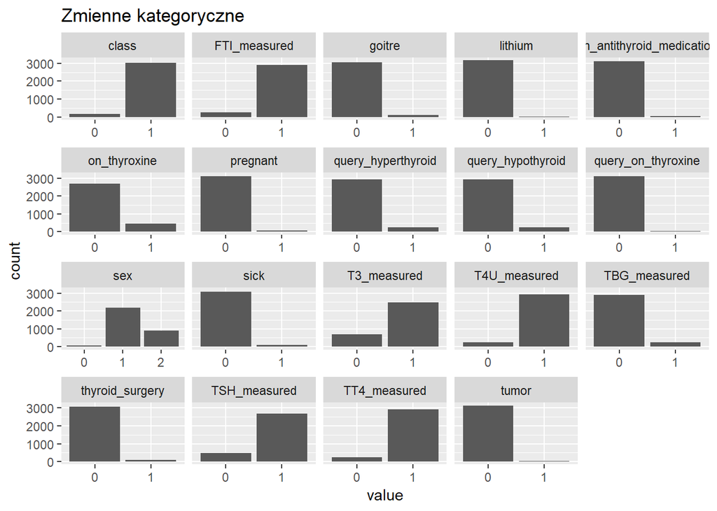

```r
podobny2 <- select(podobny, -c(age, FTI, T3, T4U, TBG, TSH,TT4))
ggplot(gather(podobny2), aes(value)) + geom_histogram(bins = 10, stat='count') + facet_wrap(~key, scales = 'free_x') + ggtitle("Zmienne kategoryczne")
```

Z tego powodu nadaliśmy mu największą wagę. Reszcie zbiorów również nadaliśmy subiektywne wagi odzwierciedlające podobieństwo do analizowanego datasetu. Na tej podstawie wyznaliczyliśmy **średnią ważoną** i wszystkie wyniki przedstawiliśmy w poniższej ramce danych:

```r
a1 <- read.csv("269.csv")
a1 <- cbind(a1, data.frame(weight = rep(1,length(a1[,1]))))
a2 <- read.csv("40676.csv")
a2 <- cbind(a2, data.frame(weight = rep(2,length(a2[,1]))))
a3 <- read.csv("40497.csv")
a3 <- cbind(a3, data.frame(weight = rep(1,length(a2[,1]))))
a4 <- read.csv("40878.csv")
a4 <- cbind(a4, data.frame(weight = rep(1.25,length(a2[,1]))))
a5 <- read.csv("40738.csv")
a5 <- cbind(a5, data.frame(weight = rep(1,length(a5[,1]))))
a3 <- select(a3, -X)
a4 <- select(a4, -X)
a5 <- select(a5, -X)
result <- rbind(a1,a2)
result <- rbind(result, a3)
result <- rbind(result, a4)
result <- rbind(result, a5)


result %>% group_by(learner.id) %>% summarise(mean = weighted.mean(auc,weight)) %>% arrange(desc(mean))
```

| learner.id | mean |
| --- | --- |
| classif.h2o.gbm | 0.8886502 |
| classif.h2o.randomForest | 0.8884091 |
| classif.boosting | 0.8847778 |
| classif.rda | 0.7551169 |
| classif.neuralnet | 0.7321119 |

Dzięki powyższym wynikom uznaliśmy, że wykorzystamy learner **h2o.gbm** jako nasz docelowy.

# 4 Tuning

Na tym etapie postaraliśmy się dobrać jak najlepsze parametry learnera **h2o.gbm**. Skupiliśmy się na dwóch zbiorach, które najbardziej przypominały nasz testowy zbiór, a więc **40676** i **40878**. Podzieliliśmy je losowo na zbiór testowy i treningowy i rozpoczęliśmy tuning hiperparametrów. Wybraliśmy zakres parametrów i za pomocą polecenia **makeTuneControlRandom** sprawdziliśmy ponad **3000** różnych ich wariacji. O ile dla zbiorów treningowych, model ze zmienionymi parametrami spisywał się lepiej - AUC rosło, o tyle dla zbioru testowego było ono niższe od trenigowego. Lepsze wyniki dla zmienionych parametrów dla zbioru treningowego potwierdziły się na wykresach, które stworzyliśmy dzięki poleceniom **plotHyperParsEffect**. Poniżej pokazaliśmy przykładowe wykresy.

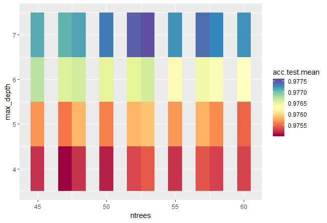

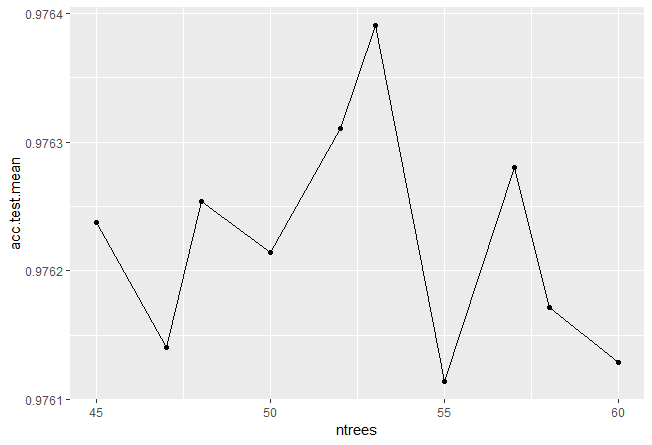

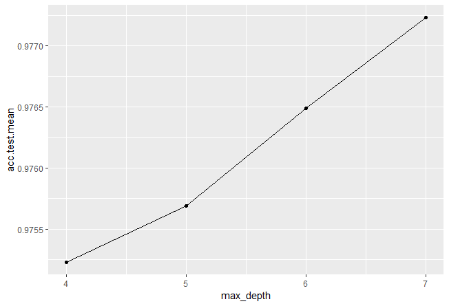

Analizując powyższe wykresy oraz otrzymane wyniki stwierdziliśmy, że podczas tuningu hiperparametrów nasz model dopasowuje się bardziej do zbioru treningowego, co nie zawsze ma dobry wpływ na otrzymywane wyniki, podczas badania zbioru testowego. W związku z tym oraz z niewiedzą dotyczącą zbioru treningowego, który otrzymamy, zdecydowaliśmy się na wykorzystanie w naszym docelowym modelu parametrów **defaultych**, które dały w naszych próbach najwyższą wartość AUC dla obu zbiorów.